# Bayesian Inference for Discrete Random Variables Ch. 6

17 Feb 2021 (*updated: 2021-02-17)*

## i. Admin & Startup

## schedule review

- Let’s review the schedule and place today’s learning in context.

## Action items

- Continue reading.
- Problem Set 3 (ch.6) was originally due Friday, but let’s push it to next Friday.
- Start early as you will have a midterm due and another hw due.

## Today’s plan

- Discuss Ch. 6 (only 1 class meeting today
- Discuss HW problems and have discussion.

*Please contribute questions and comments*

## Bayesian inference for discrete using a table

Discuss the introductory section in Ch.6. Show Table 6.1, 6.2, 6.3.

## Discuss notational change:

\(f(x_i, y_j) = g(x_i) \times f(y_j | x_i)\).

Why \(g(\cdot)\) and \(f(\cdot)\)?

## Bayes` theorem (again):

\(f(x_i | y_j) = \frac{g(x_i) \times f(y_j | x_i)}{\sum_{i=1}^n g(x_i) \times f(y_j | x_i)}\).

Let’s label and discuss the parts of the above formula.

## Activity break: Example 6.1

Review Example 6.1, p. 112 - 114. Discuss the steps for Bayes’ Theorem using a table with your near peers. Then a volunteer will explain to the class.

## II. Using the `Bolstad` R package

## Demonstration: one at time or all at once?

Imagine we observe 8 independent trials of a random experiment and each has one of two possible outcomes (success = 1 and failure = 0). We’d like to infer what the (unobservable) probability of success is, given the data. Suppose we observe the sequence:

11011101

## `Bolstad` R package

First let’s install and load the package:

```r
## install.packages("Bolstad")
library(Bolstad)

## help(package = "Bolstad")

## Ch.6, Exercise C1
## for help
## ?binodp
```

## One observation at a time

Now let’s revise our belief about the probability of success, \(\pi\), by computing Bayes’ rule one observation at a time.

```r
## the observed values
observed_seq <- c(1,1,0,1,1,1,0,1)
## uniform discrete prior, using a grid of 10 values
my_pi <- seq(0, 1, length.out = 10)
my_pi.prior <- rep( 1 / length(my_pi), length(my_pi) )
```

## Sequentially updating

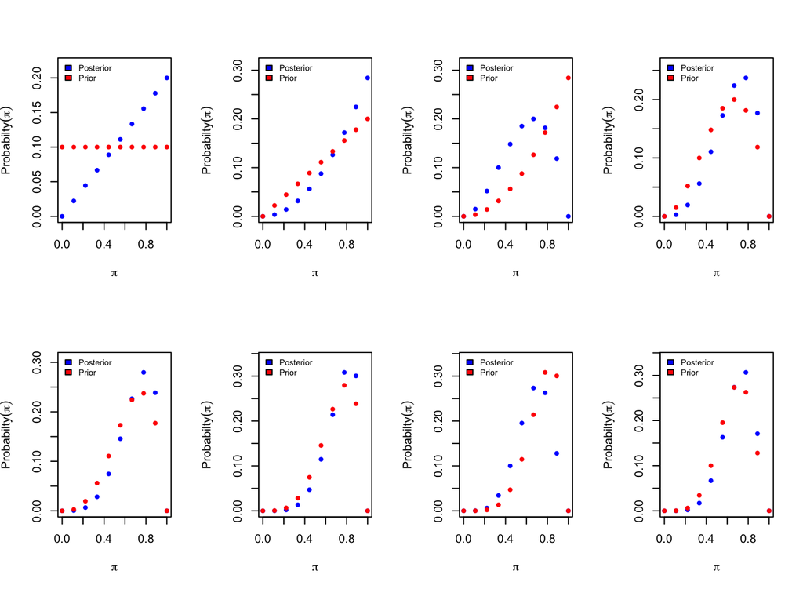

## Now let’s compute this all at once:

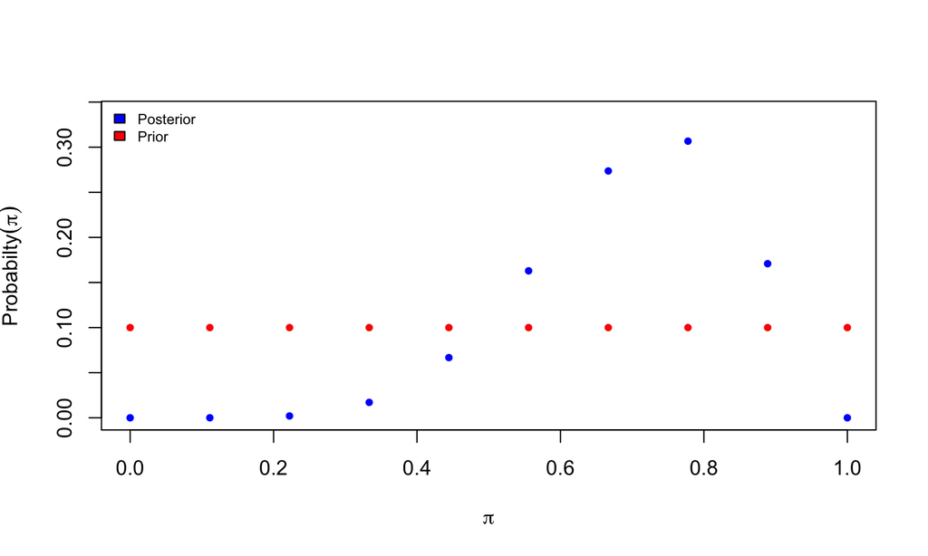

```
## Conditional distribution of x given pi and  n:
##
##            0      1      2      3      4      5      6      7      8
## 0     1.0000 0.0000 0.0000 0.0000 0.0000 0.0000 0.0000 0.0000 0.0000
## 0.111 0.3897 0.3897 0.1705 0.0426 0.0067 0.0007 0.0000 0.0000 0.0000
## 0.222 0.1339 0.3061 0.3061 0.1749 0.0625 0.0143 0.0020 0.0002 0.0000
## 0.333 0.0390 0.1561 0.2731 0.2731 0.1707 0.0683 0.0171 0.0024 0.0002
## 0.444 0.0091 0.0581 0.1626 0.2602 0.2602 0.1665 0.0666 0.0152 0.0015
## 0.556 0.0015 0.0152 0.0666 0.1665 0.2602 0.2602 0.1626 0.0581 0.0091
## 0.667 0.0002 0.0024 0.0171 0.0683 0.1707 0.2731 0.2731 0.1561 0.0390
## 0.778 0.0000 0.0002 0.0020 0.0143 0.0625 0.1749 0.3061 0.3061 0.1339
## 0.889 0.0000 0.0000 0.0000 0.0007 0.0067 0.0426 0.1705 0.3897 0.3897
## 1     0.0000 0.0000 0.0000 0.0000 0.0000 0.0000 0.0000 0.0000 1.0000
##
## Joint distribution:
##
##            0      1      2      3      4      5      6      7      8
##  [1,] 0.1000 0.0000 0.0000 0.0000 0.0000 0.0000 0.0000 0.0000 0.0000
##  [2,] 0.0390 0.0390 0.0171 0.0043 0.0007 0.0001 0.0000 0.0000 0.0000
##  [3,] 0.0134 0.0306 0.0306 0.0175 0.0062 0.0014 0.0002 0.0000 0.0000
##  [4,] 0.0039 0.0156 0.0273 0.0273 0.0171 0.0068 0.0017 0.0002 0.0000
##  [5,] 0.0009 0.0058 0.0163 0.0260 0.0260 0.0167 0.0067 0.0015 0.0002
##  [6,] 0.0002 0.0015 0.0067 0.0167 0.0260 0.0260 0.0163 0.0058 0.0009
##  [7,] 0.0000 0.0002 0.0017 0.0068 0.0171 0.0273 0.0273 0.0156 0.0039
##  [8,] 0.0000 0.0000 0.0002 0.0014 0.0062 0.0175 0.0306 0.0306 0.0134
##  [9,] 0.0000 0.0000 0.0000 0.0001 0.0007 0.0043 0.0171 0.0390 0.0390
## [10,] 0.0000 0.0000 0.0000 0.0000 0.0000 0.0000 0.0000 0.0000 0.1000
##
## Marginal distribution of x:
##
##           0      1      2      3   4      5      6      7      8
## [1,] 0.1573 0.0928 0.0998 0.1001 0.1 0.1001 0.0998 0.0928 0.1573
##
##
##       Prior   Likelihood    Posterior
## 0       0.1 0.000000e+00 0.000000e+00
## 0.111   0.1 4.162919e-05 4.170772e-05
## 0.222   0.1 2.039830e-03 2.043678e-03
## 0.333   0.1 1.707057e-02 1.710277e-02
## 0.444   0.1 6.660670e-02 6.673236e-02
## 0.556   0.1 1.626140e-01 1.629208e-01
## 0.667   0.1 2.731291e-01 2.736444e-01
## 0.778   0.1 3.061020e-01 3.066795e-01
## 0.889   0.1 1.705132e-01 1.708348e-01
## 1       0.1 0.000000e+00 0.000000e+00
```

```r
par(mfrow = c(1,1))
binodp(x = 6, n = 8)
```

Does our inference about \(\pi\) change?

## Two equivalent ways of using Bayes’ Theorem

Discuss Table 6.7 - 6.10 and notational challenges.

## Using Bayes’ rule for binomial and Poisson rvs with discrete prior

Discuss example 6.2 and 6.3, briefly.

## III. Ch. 6 HW

## Homework Q & A

- read and discuss prompts